# Day 4

## Review

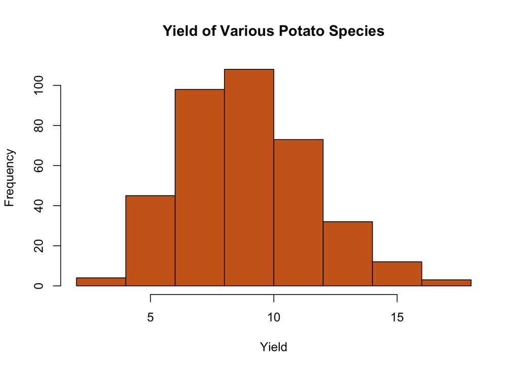

Which way is this histogram **skewed**?

How would you describe the **“center”** of this data?

Numerical summaries help us **understand data sets faster**

Notation is how we communicate statistical/mathematical equations:

Data values can be denoted as $x_1,x_2,x_3,...$

- $x_1$ refers to the observed value of the **variable** $x$ from **individual** 1

**Summation**

- This is referring to the sum (addition) of everything contained in the expression
- We denote this with the Greek letter $\Sigma$

$$\sum\limits_{i=1}^nx_i=x_1+x_2+...+x_n$$

#### Mean

- Balance point (fulcrum) of the dataset
- Population mean (denoted $\mu$):

$$\mu = {1 \over N}\sum\limits_{i=1}^Nx_i$$

$$\mu = {\sum\limits_{i=1}^Nx_i\over N}$$

$$N \approx 10000$$

$$\mu = {1 \over 10000}(x_1 + x_2 +x_3 + ...+x_{10000})$$

$$\mu = 1258.771$$

- Is $\mu$ a statistic?

*Properties of the mean:*

- Common
- Easy to interpret
- Susceptible to **outliers**
  - A statistic is **resistant** if its value is not affected heavily by outliers

#### Median

**Middle value, half the data are below and half are above**

$$\begin{array}{|c|c|c|c|c|c|c|c|c|c|}
\hline
1149 & 1577 & 1138 & 1319 & 1399 & 1074 & 1091 & 1324 & 1048 & 1462 \\
\hline
\end{array}$$

Sort your data in **increasing** order (low to high)

$$\begin{array}{|c|c|c|c|c|c|c|c|c|c|}
\hline
1048 & 1074 & 1091 & 1138 & 1149 & 1319 & 1324 & 1399 & 1462 & 1577 \\
\hline
\end{array}$$

If $n$ is **odd**: choose position ${(n+1)\over2}$ in the ordered dataset

If $n$ is **even** *after ordering*:

- Pick $n\over 2$ and ${n \over 2}+1$
- Average the two data points

$${10\over2}=5 \ , \ {10 \over2}+1=6$$

*Properties of median:*

- It doesn’t use all of the data directly
- This makes it **resistant**
  - Outliers have little/no effect
- Difference between median and mean depend on *skew* of the histogram

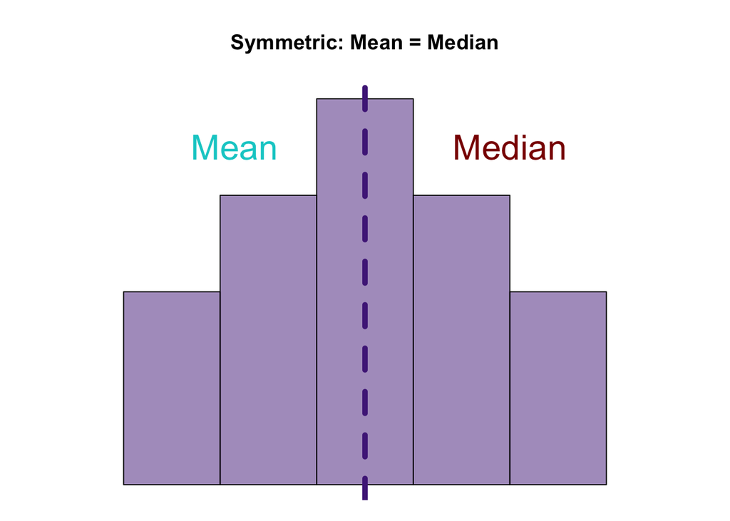

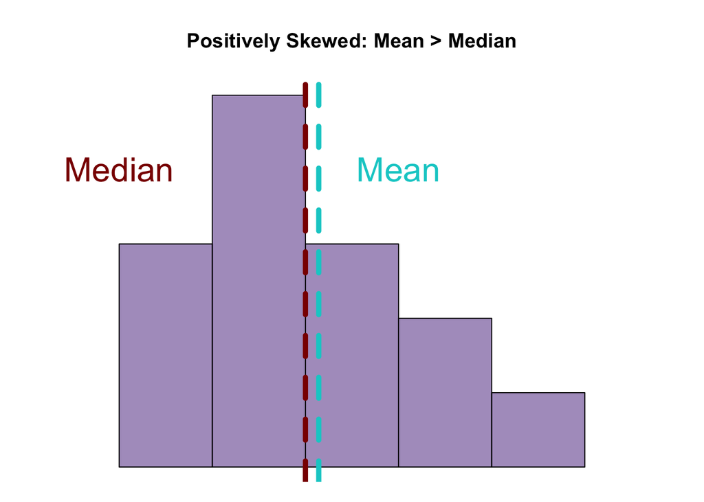

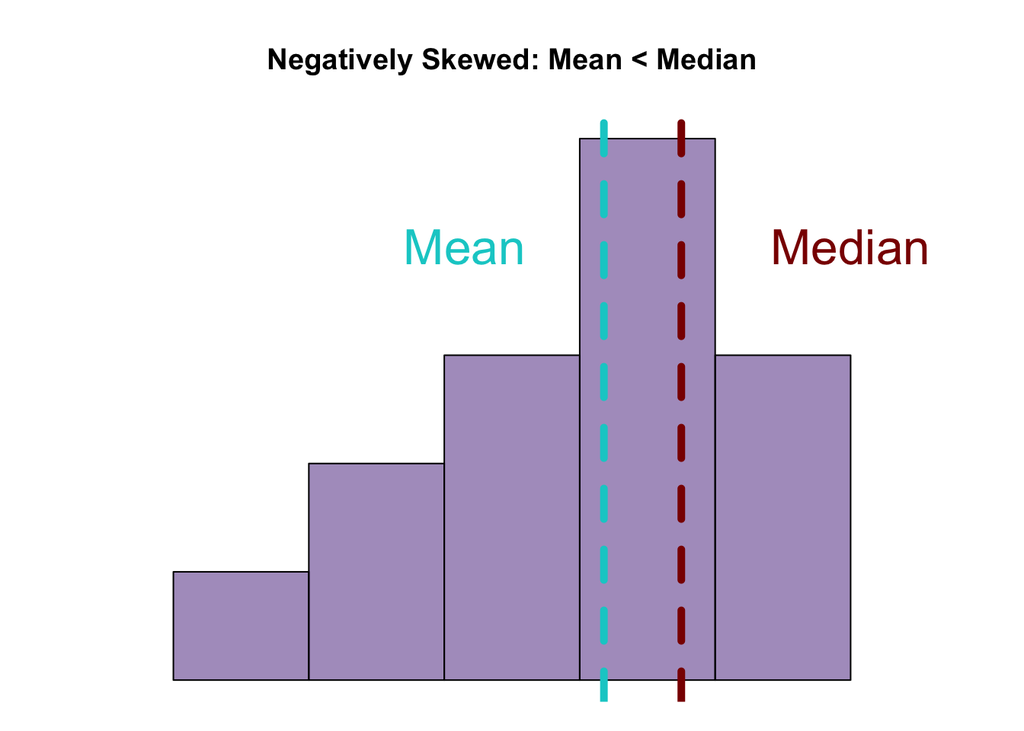

#### Mode

**The most frequent observation**

**Where the peak is**

- What **could be** the mode here?

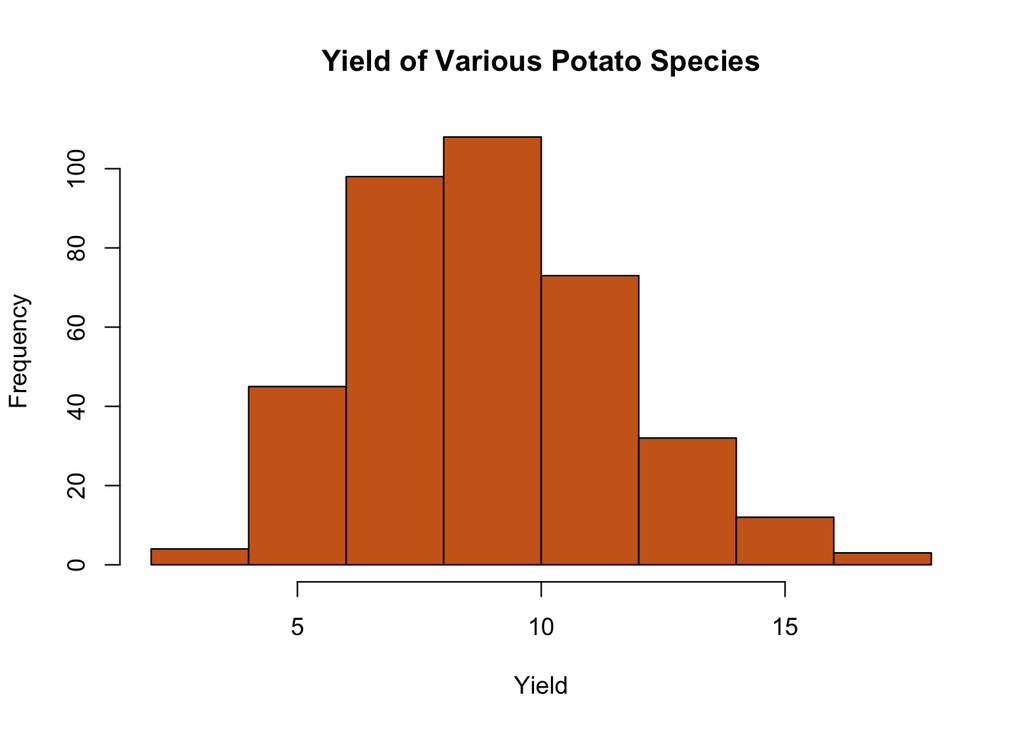

Useful for qualitative data

Not as useful for quantitative data

A data set can have any number of modes $(0,1,2,...)$

$$\begin{array}{|c|c|c|c|c|c|c|c|c|}
\hline
8 & 10 & 7 & 11 & 14 & 12 & 11 & 9 & 14 \\
\hline
11 & 8 & 2 & 8 & 10 & 7 & 12 & 11 & 8 \\
\hline
\end{array}$$

Whatever method works best for you is the one you use

**Questions?**

**Goals for Today:**

1. Introduce the measures of spread: Range, Variance, and Standard Deviation
2. Describe the Empirical rule

## Numerical Summaries of Data

### Measures of Spread

Statistics is *roughly* about making inference from data

- Is it **fair** to make inference from mean/median/mode alone?
  - Is the mean resistant?
  - Is the median representative of all the data?
  - Does the mode tell us about outliers?
- When we look at data there’s a certain **spread** to it:

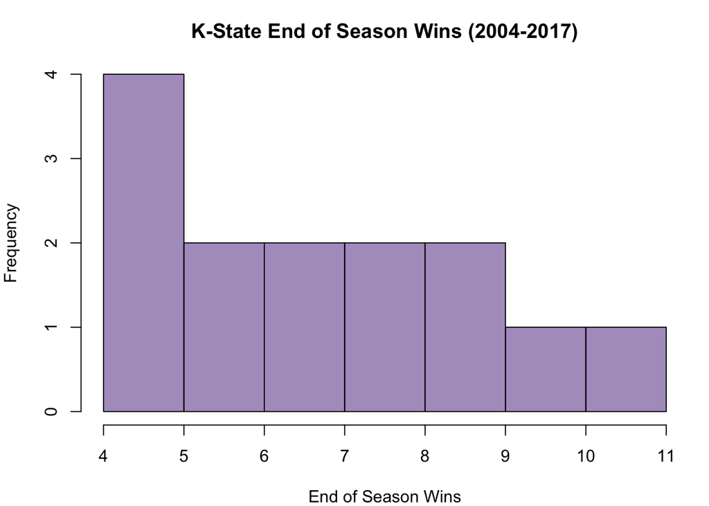

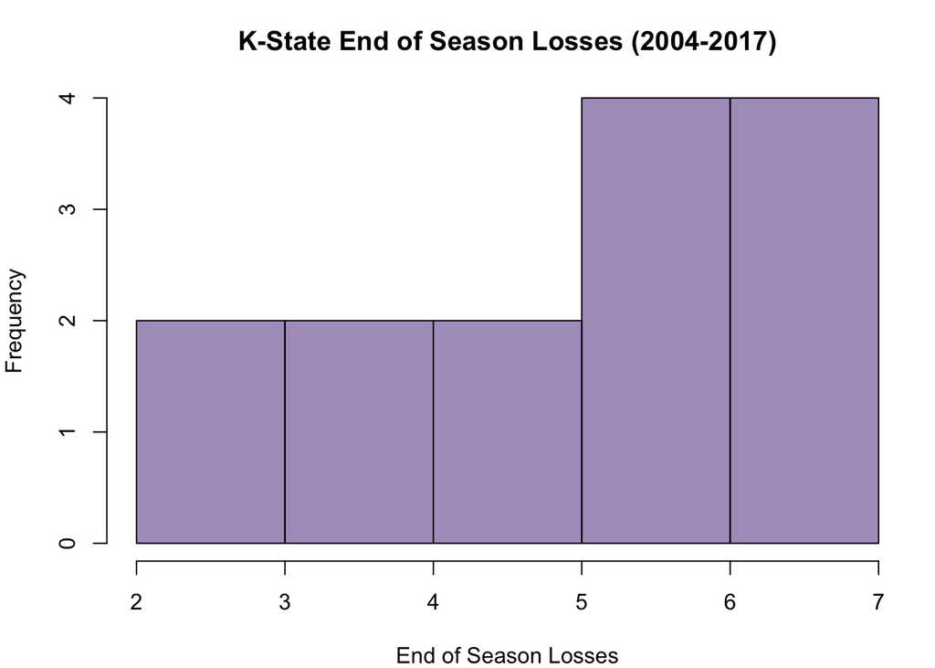

- **Spread** is an important metric for understanding the **differences** or **variation** in data

### Range

**Difference between the largest and smallest data value**

- Simplest measure of spread

$$\text{Range} = \text{Maximum} - \text{Minimum}$$

Calculate the mean and range of the aboveground biomass for Clover Species A and Clover Species B in this data set:

$$\begin{array}{|c|c|c|c|c|c|c|c|c|}
\hline
\text{Species A} & 3.11 & 2.95 & 2.00 & 2.62 & 3.34 & 3.41 & 2.13 & 2.81 & 1.80 & 2.89 \\
\hline
\text{Species B} & 3.43 & 3.33 & 3.03 & 3.40 & 3.32 & 3.13 & 2.81 & 3.04 & 3.38 & 3.24 \\
\hline
\end{array}$$

**What do our results mean?**

With every measure/metric there’s good and bad

- Range **does** let us look at spread
  - It’s imperfect

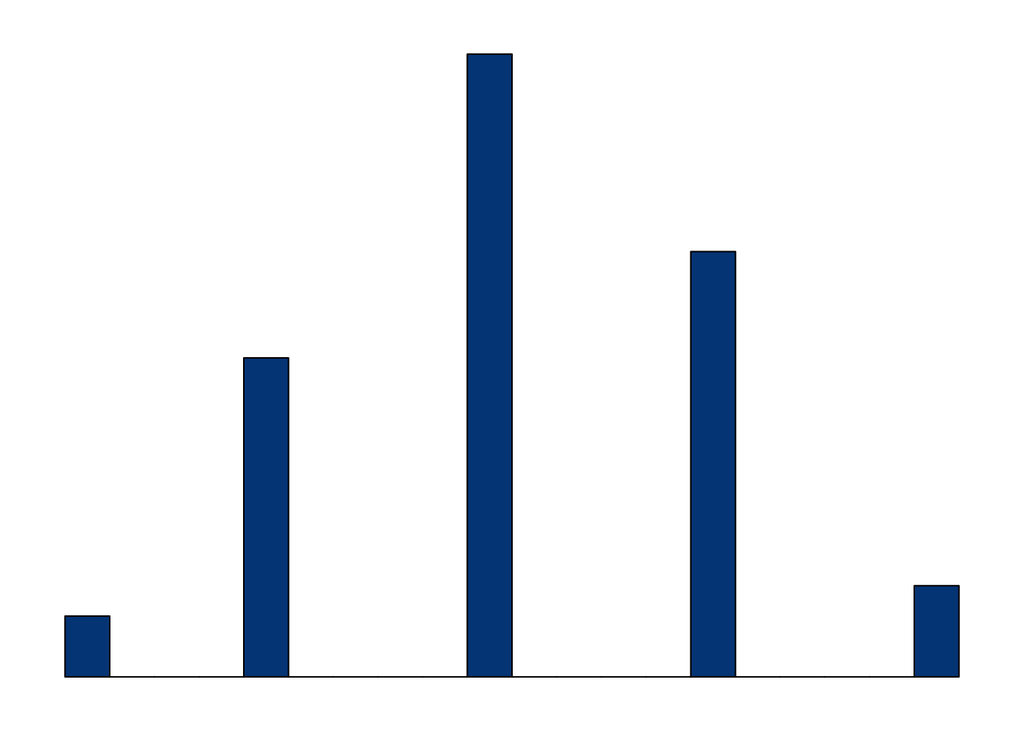

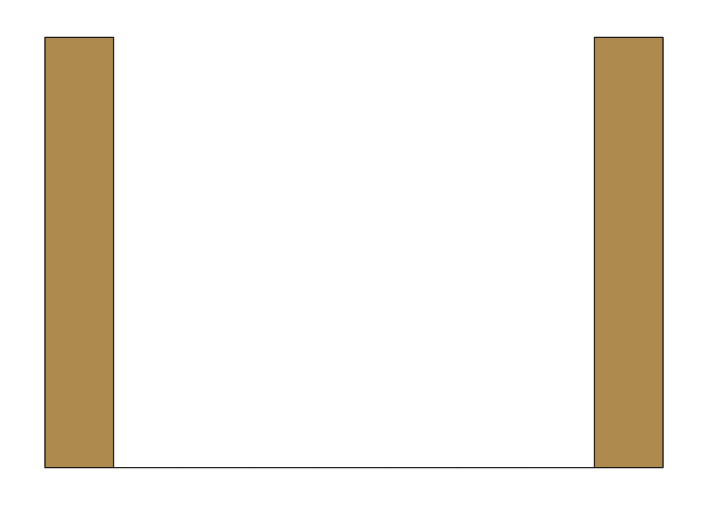

These two data sets could have the same range **and** mean

- Are they the same data set if that’s true?

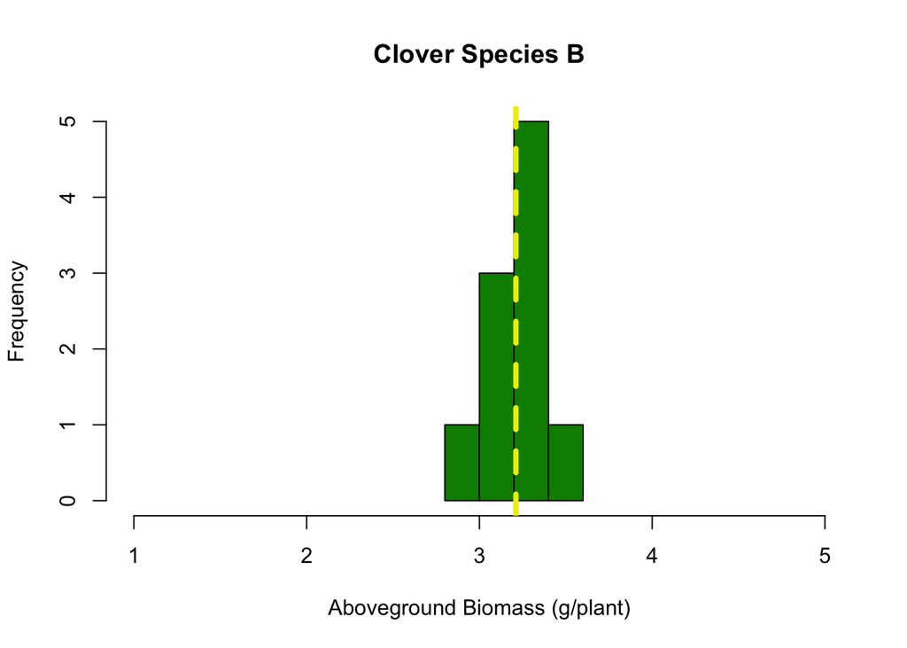

- Smaller spread is usually **closer to the mean**

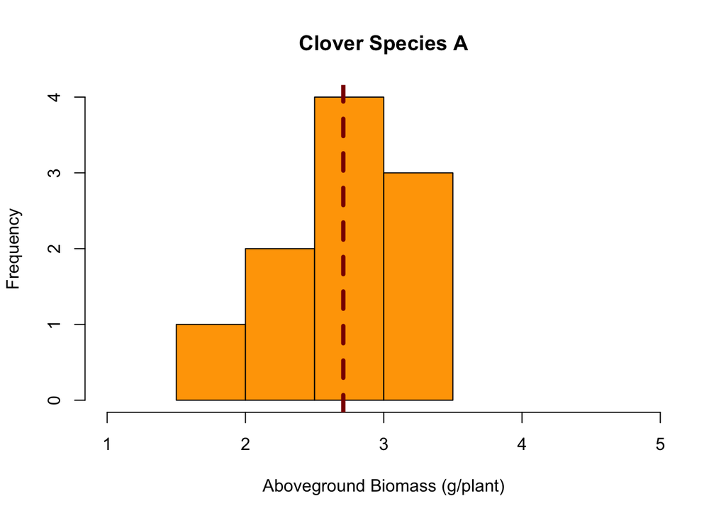

- Larger spread is usually **further from the mean**

### Variance

**Measure of how far, on average, values in a data set are from the mean**

- Population mean (denoted $\mu$):

$$\mu = {1 \over N}\sum\limits_{i=1}^Nx_i$$

$$\mu = {\sum\limits_{i=1}^Nx_i\over N}$$

- Sample mean (denoted $\bar{x}$)

$$\bar{x} = {1 \over n}\sum\limits_{i=1}^nx_i$$

$$\bar{x} = {\sum\limits_{i=1}^nx_i\over n}$$

Let $x_1,x_2,...,x_N$ be values in a population of $N$ size

- The **difference** between $i^{th}$ population value and the mean is:

$$x_i - \mu$$

- We want to take these differences from $1$ to $i$ and divide them by $N$

**There’s a problem though:**

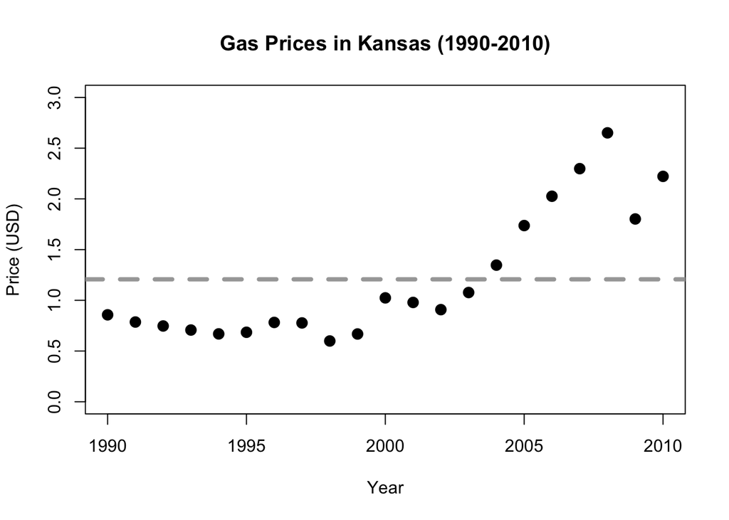

- Positive and negative difference can cancel out
- We can fix that by squaring the value of each difference:

$$(x_i - \mu)^2$$

**Given this:**

- Variance should **never be negative**
- Zero or positive

**Larger** variance means **more variability**

- **Population variance** (denoted $\sigma^2$):

$$\sigma^2 = {{{\sum\limits_{i=1}^N}(x_i-\mu)^2}\over N}$$

- **Sample variance** (denoted $s^2$):

$$s^2 = {{{\sum\limits_{i=1}^n}(x_i-\bar{x})^2}\over (n-1)}$$

Remember that statistics is *roughly*:

> Making inference about a population parameter using sample statistics

In practice we **almost never** have a population variance

- We use a sample variance to **estimate** population variance

**Given the data on gas prices in Kansas below**

$$\begin{array}{|c|c|c|c|c|c|c|c|c|}
\hline
\text{Year} & 2004 & 2005 & 2006 & 2007 &2008 & 2009 & 2010 \\
\hline
\text{Price} & 1.347 & 1.737 & 2.026 & 2.298 & 2.651 & 1.802 & 2.222 \\
\hline
\end{array}$$

$$\bar{x}=2.012$$

1. Calculate the sample variance

$$s^2 = {{{\sum\limits_{i=1}^n}(x_i-\bar{x})^2}\over (n-1)}$$

2. Attempt to calculate the sample variance without the squaring step

$$s^2 = {{{\sum\limits_{i=1}^n}(x_i-\bar{x})}\over (n-1)}$$

3. Attempt to calculate the sample variance by adding up all of the points:

$$\sum\limits_{i=1}^n x_i$$

Then subtracting them from the sample mean ($\bar{x}$), squaring the result, and dividing by $n-1$

### Standard Deviation

Variance is a squared unit of the data

- It’s annoying to think in squares

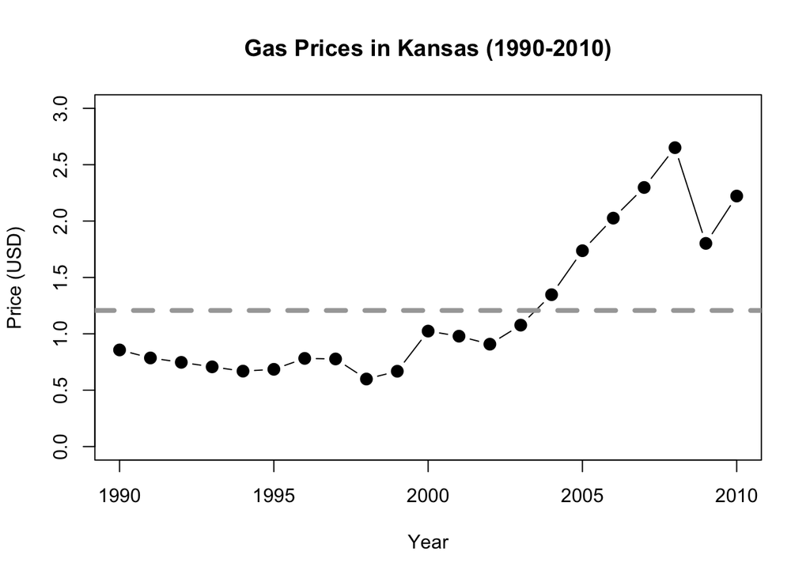

The **units** for the variance we calculated in the previous example is “$\text{Dollars}^2$”

- This is an easy fix:

$$\sqrt{\text{Dollars}^2}=\text{Dollars}$$

This is called **standard deviation**

- It lets us work in the original units of the data

The notation is simple enough as well:

$$\sqrt{\sigma^2}=\sigma \rightarrow \text{Population Standard Deviation}$$

$$\sqrt{s^2}=s \rightarrow \text{Sample Standard Deviation}$$

In the previous example we calculated *variance*

- What would be the **standard deviation**?

$$\begin{array}{|c|c|c|c|c|c|c|c|c|}
\hline
\text{Year} & 2004 & 2005 & 2006 & 2007 &2008 & 2009 & 2010 \\
\hline
\text{Price} & 1.347 & 1.737 & 2.026 & 2.298 & 2.651 & 1.802 & 2.222 \\
\hline
\end{array}$$

$$\bar{x}=2.012$$

How does that compare to your answer in question (2) of the example problem?

> Attempt to calculate the sample variance without the squaring step

### Empirical Rule

Many data sets have a single peak in the center and an approximately symmetric shape

- We call this a **bell-shape**

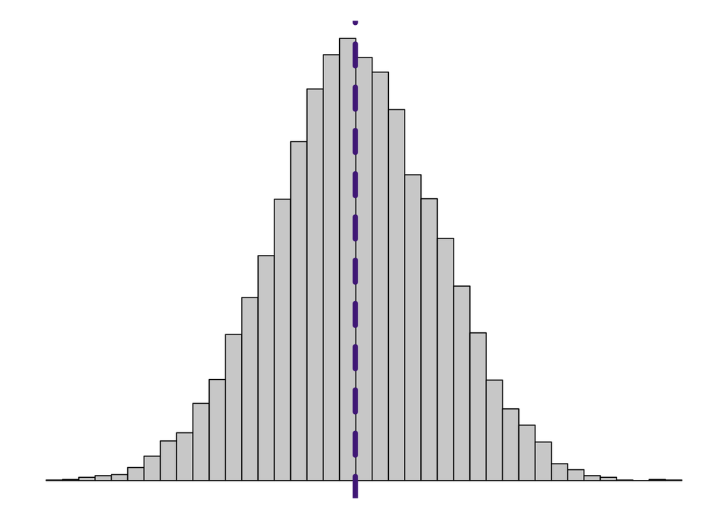

When we see this distribution:

- We can use **standard deviation** to describe how much of the data is within a certain **range** of the **mean**

*The Empirical Rule*

For a population that has an *approximately* **bell-shaped** distribution:

- $\approx 68\%$ of the data is within **ONE** standard deviation of the mean

$$\approx 68\% = \begin{cases}
\mu - \sigma \\
\mu + \sigma
\end{cases}$$

- $\approx 95\%$$ of the data is within **TWO** standard deviations of the mean

$$\approx 95\% = \begin{cases}
\mu - 2\sigma \\
\mu + 2\sigma
\end{cases}$$

- $\approx$ **All** or *almost all* of the data is within **THREE** standard deviations of the mean

$$\approx 100\% = \begin{cases}
\mu - 3\sigma \\
\mu + 3\sigma
\end{cases}$$

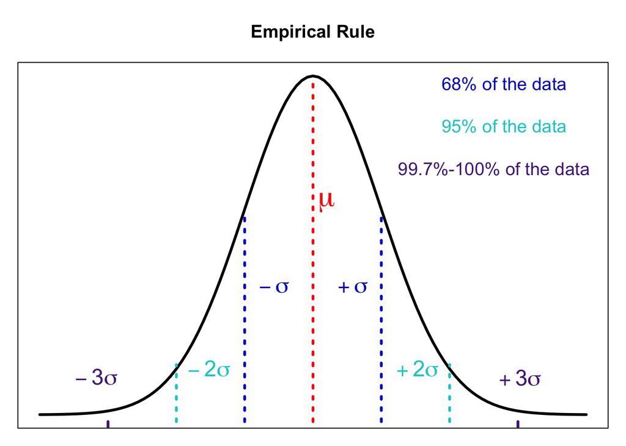

> A researcher for KDWP records the weight of 250 raccoons that have been captured as part of a culling effort. The raccoons had sample mean weight of $\bar{x} = 15$ pounds and sample standard deviation $s = 2$ pounds. The histogram is approximately bell-shaped.
1. Find an interval that is likely to contain approximately $68\%$ of the scores
2. Approximately what percentage of the raccoons were between $11$ and $19$ pounds?
3. Approximately how many raccoons were between $11$ and $19$ pounds?

### Attendance QOTD

$$\begin{array}{|c|c|c|c|c|}
\hline
12 & 8 & 7 & 5 & 6 & 4 & 15 \\
\hline
\end{array}$$